# The Central Limit Theorem

### CLT for means

Let’s assume the actual population mean is $\mu$, the population standard deviation is $\sigma$, and we consider samples of size $n$.

- **Assumptions:** For most populations, if $n>30$ then we can assume the Central Limit Theorem applies reasonably well.
- **Result:** The sampling distribution of sample means ($\bar x$) can be modeled with a normal distribution where
  - the mean is $\mu$, and
  - the standard deviation is $\sigma/\sqrt{n}$.

**Example.** We already generated *simulated sampling distribution* of mean heights for our `people` data under the name `samp_dist_means`, assuming samples of size 50. Moreover, recall that the population of heights had the following parameters:

```r
people %>% summarise(
    mean = mean(heights),
    sd = sd(heights)
)
```

| mean | sd |
| --- | --- |
| 65.577 | 3.463829 |

Let’s compare the sampling distribution against the CLT predictions!

```r
# CLT parameters
# mu = ...
mu <- 65.577

# sigma = ...
sigma <- 3.463829/sqrt(50)

#On your own, try out a probability versus percentage comparison
# Compare the rel. frequency of mean height for a group of 50 is less than 65 inches
sum(samp_dist_means < 65)/length(samp_dist_means)
```

```
## [1] 0.12
```

```r
# to the probability predicted by the CLT
pnorm(65, mu, sigma)
```

```
## [1] 0.1194204
```

Try comparing rel. frequencies against probability for sample means between 65 and 66 inches:

```r
sum(samp_dist_means < 66)/length(samp_dist_means) -
    sum(samp_dist_means < 65)/length(samp_dist_means)
```

```
## [1] 0.687
```

```r
pnorm(66, mu,sigma) - pnorm(65, mu, sigma)
```

```
## [1] 0.6866519
```

Let’s visualize:

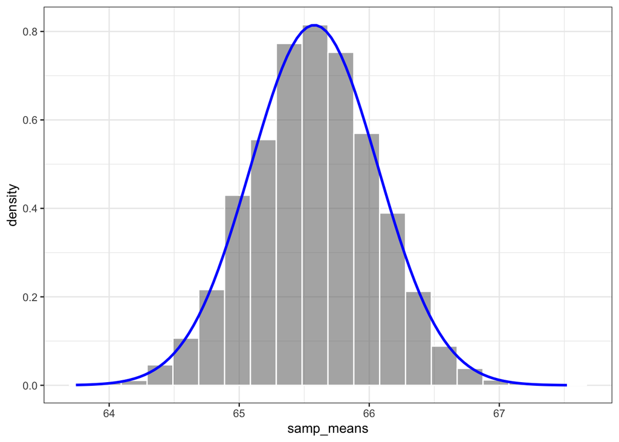

```r
compare_sampdist_norm(samp_dist_means,mu,sigma, bins = 20)
```

## Wait just a minute…

*Since when* do we know population parameters like $p$, or $\mu$ and $\sigma$?

And what about these *Assumptions*; what if we don’t meet them? Then what?

Yes, well, we keep adapting.

Hopefully though, you’re at least convinced that we can replace the *simulated sampling* approach with an appropriate probability model, and still accurately compute probabilities and estimate the standard deviation of a sampling distribution.

## Central Limit Theorem Problems

In the examples we present below, we start laying the foundation for how we will use the Central Limit Theorem to do statistical inference. In addition to applying the Central Limit Theorem, we explore the *logic* and important ideas that underly our two main techniques.

### An application with percentages (Hypothesis Testing)

Suppose that a friend of your claims that 50% of all Labrador Retrievers have a brown coat (chocolate labs). You are pretty sure that your friend is wrong, but how can you demonstrate that?

You decide to use a data driven approach, and so through the American Kennel Club, you get a random sample of 100 Labrador Retrievers: `labradors`.

1. What percentage *of your sample* have brown coat?

```r
# place code here
labradors %>%
    select(coat) %>%
    table() %>% prop.table()
```

```
## coat
##  black  brown yellow
##   0.48   0.23   0.29
```

Our sample percentage is 23%, $\hat p = 0.23$.

*IF I assume my friend is right, I get to assume the population percentage $p = 0.5$.*

What are my CLT params assuming my friend is right?

```r
mu <- 0.5
sigma <- sqrt(0.5*(1-0.5)/100)
sigma
```

```
## [1] 0.05
```

2. *Assuming your friend is **correct***, what percentage of the sample would you have expected? Why?

**Answer**: I should be seeing sample percentages around 50%, if my friend is right. This is because the CLT tells us the sample percentages, on average, equal the population percentage of 50% (assuming, again, my friend is right).

3. Does your sample summary seem “likely” *if your friend is correct?* Why or why not?

**Answer:** A sample percentage of 23% wouldn’t happen very often according to the CLT; it should around 50% with some variation. In fact, our standard deviation of the sampling distribution (Standard Error) is about 5%, so anything outside of the 40% - 60% range is unusual due to the Empirical Rule.

4. *Assuming your friend is **correct***, what would the sampling distribution of the percentage of chocolate labs look like according to the central limit theorem (CLT)?
5. Using the normal distribution from the previous exercise, compute the probability of getting a sample percentage *like yours* (answer to question 1), or something smaller?

```r
pnorm(0.23, .5, sqrt(.5*(1-.25)/100) )
```

```
## [1] 5.190497e-06
```

(We’ll call these $P$-values soon…)

6. Is the probability from question 5 big or small? Explain how this provides evidence against your friend’s claim.

### An application with means (Confidence Intervals)

Your sample of 100 Labrador retrievers also contains information on their weights, and we want to use that to make an educated *guess* about the mean weight for *all* Labradors ($\mu$).

```r
labradors %>%
    summarize(
        meanWT = mean(weights),
        sdWT = sd(weights),
        sample_size = n()
    )
```

| meanWT | sdWT | sample_size |
| --- | --- | --- |
| 71.9884 | 9.030984 | 100 |

1. According to the central limit theorem, what is the mean and standard deviation of the sampling distribution of mean weights? (Your answer should be in terms of the population parameters $\mu$ and $\sigma$, the mean and standard deviation of individual Labrador weights.)

mean = $\mu$, the population mean weight for labs sd = $\sigma/\sqrt{n}$, where $\sigma$ is the population std. deviation.

2. According to the central limit theorem, will the sampling distribution of sample mean weights be normally distributed?

Yes, because we have n = 100, which is much more than 30.

2. Does the *Empirical Rule* apply to the sampling distribution of sample mean weights? If so, where should we expect 95% of potential sample means to fall?

It should fall within $2\sigma/\sqrt{n}$ from the actual population mean; in the interval:
$$(\mu -
2\sigma/\sqrt{n}, \mu + 2\sigma/\sqrt{n})$$

3. Said differently, for this “middle 95%” of potential sample mean guesses, we will be at least how close to the actual population mean $\mu$?

95% of the time, I’ll be within $2\sigma/\sqrt{n}$ from the actual population mean I’m trying to estimate!

- It’s likely that I’m in the middle, although I don’t know whether I’m bigger or smaller than the actual population mean $\mu$.

So I will guess an *interval* based on my sample mean, and widen by $2\sigma/\sqrt{n}$.

- Wait, I don’t know $\sigma$, so I’ll use my sample standard deviation as the best I can do to replace it.

Guess:

```r
71.9884 + c(-2,2)*9.030984/sqrt(100)
```

```
## [1] 70.1822 73.7946
```

4. Would increasing our sample size lead to guesses that are closer or farther away from the population mean? Can you use the CLT to explain why?

Increasing the sample size leads to a smaller value for $\sigma/\sqrt{n}$, according to the CLT. This is roughly a measure of how close our guesses are to the actual population parameter. This means larger sample sizes tend to lead to guesses that are close to the parameter we are trying to find.